# Project 1: Wrangling, Exploration, Visualization

SDS322E

## Data Wrangling, Exploration, Visualization

### Mohamed Bettayeb, mb58422

#### Introduction

The first dataset I chose was a set of data that observed different happiness levels across different countries. The variables of this dataset include the country, the region, the happiness rank relative to other countries, the overall happiness score, the standard error of that happiness score, and then the constitutes of this score (the gdp per capita, family life, life expectancy, trust in the government, generosity, and dystopia residual). The other dataset I chose involved the ranking of colleges across the world. This dataset included the variables of the institution name, the country it is located, the national rank of the institute, the year, the score, and the constitutes of this score which include the quality of the education, quality of the faculty, the number of publications, the number of citations, the broad impact, the rate of employment among alumni, the influence, and the number of patents. I chose these two datasets I thought it would be rather interesting to see if there was any sort of correlation between countries with more competitive schools and the overall happiness level of the country.

```r
library(tidyverse)
library(readr)
library(dplyr)
library(gt)
happiness <- read_csv("2015.csv")
college <- read_csv("cwurData.csv")
```

#### Tidying: Reshaping

Both of these datasets are already tidy, therefore all I did here was untidy them and then retidy them. However, I did also utilize str_replace_all to change the “USA” in the college dataset into “United States” in order to allow for easier joining in the next step.

```r
college <- college %>% mutate(country=str_replace_all(country, "USA","United States"))
glimpse(college)
```

```
## Rows: 2,200
## Columns: 14
## $ world_rank           <dbl> 1, 2, 3, 4, 5, 6, 7, 8, 9, 10, 11, 12, 13, 14, 15…
## $ institution          <chr> "Harvard University", "Massachusetts Institute of…
## $ country              <chr> "United States", "United States", "United States"…
## $ national_rank        <dbl> 1, 2, 3, 1, 4, 5, 2, 6, 7, 8, 9, 10, 11, 1, 12, 1…
## $ quality_of_education <dbl> 7, 9, 17, 10, 2, 8, 13, 14, 23, 16, 15, 21, 31, 3…
## $ alumni_employment    <dbl> 9, 17, 11, 24, 29, 14, 28, 31, 21, 52, 26, 42, 16…
## $ quality_of_faculty   <dbl> 1, 3, 5, 4, 7, 2, 9, 12, 10, 6, 8, 14, 24, 31, 20…
## $ publications         <dbl> 1, 12, 4, 16, 37, 53, 15, 14, 13, 6, 34, 22, 9, 8…
## $ influence            <dbl> 1, 4, 2, 16, 22, 33, 13, 6, 12, 5, 20, 21, 10, 19…
## $ citations            <dbl> 1, 4, 2, 11, 22, 26, 19, 15, 14, 3, 28, 16, 8, 23…
## $ broad_impact         <dbl> NA, NA, NA, NA, NA, NA, NA, NA, NA, NA, NA, NA, N…
## $ patents              <dbl> 5, 1, 15, 50, 18, 101, 26, 66, 5, 16, 101, 10, 9,…
## $ score                <dbl> 100.00, 91.67, 89.50, 86.17, 85.21, 82.50, 82.34,…
## $ year                 <dbl> 2012, 2012, 2012, 2012, 2012, 2012, 2012, 2012, 2…
```

```r
college_wide <- college %>% pivot_wider(names_from="year", values_from="score") %>% glimpse()
```

```
## Rows: 2,199
## Columns: 16
## $ world_rank           <dbl> 1, 2, 3, 4, 5, 6, 7, 8, 9, 10, 11, 12, 13, 14, 15…
## $ institution          <chr> "Harvard University", "Massachusetts Institute of…
## $ country              <chr> "United States", "United States", "United States"…
## $ national_rank        <dbl> 1, 2, 3, 1, 4, 5, 2, 6, 7, 8, 9, 10, 11, 1, 12, 1…
## $ quality_of_education <dbl> 7, 9, 17, 10, 2, 8, 13, 14, 23, 16, 15, 21, 31, 3…
## $ alumni_employment    <dbl> 9, 17, 11, 24, 29, 14, 28, 31, 21, 52, 26, 42, 16…
## $ quality_of_faculty   <dbl> 1, 3, 5, 4, 7, 2, 9, 12, 10, 6, 8, 14, 24, 31, 20…
## $ publications         <dbl> 1, 12, 4, 16, 37, 53, 15, 14, 13, 6, 34, 22, 9, 8…
## $ influence            <dbl> 1, 4, 2, 16, 22, 33, 13, 6, 12, 5, 20, 21, 10, 19…
## $ citations            <dbl> 1, 4, 2, 11, 22, 26, 19, 15, 14, 3, 28, 16, 8, 23…
## $ broad_impact         <dbl> NA, NA, NA, NA, NA, NA, NA, NA, NA, NA, NA, NA, N…
## $ patents              <dbl> 5, 1, 15, 50, 18, 101, 26, 66, 5, 16, 101, 10, 9,…
## $ `2012`               <dbl> 100.00, 91.67, 89.50, 86.17, 85.21, 82.50, 82.34,…
## $ `2013`               <dbl> NA, NA, NA, NA, NA, NA, NA, NA, NA, NA, NA, NA, N…
## $ `2014`               <dbl> NA, NA, NA, NA, NA, NA, NA, NA, NA, NA, NA, NA, N…
## $ `2015`               <dbl> NA, NA, NA, NA, NA, NA, NA, NA, NA, NA, NA, NA, N…
```

```r
college_long <- college_wide %>% pivot_longer(cols=starts_with('20'), names_to="year",values_to="score", values_drop_na=TRUE) %>% glimpse()
```

```
## Rows: 2,200
## Columns: 14
## $ world_rank           <dbl> 1, 2, 3, 4, 5, 6, 7, 8, 9, 10, 11, 12, 13, 14, 15…
## $ institution          <chr> "Harvard University", "Massachusetts Institute of…
## $ country              <chr> "United States", "United States", "United States"…
## $ national_rank        <dbl> 1, 2, 3, 1, 4, 5, 2, 6, 7, 8, 9, 10, 11, 1, 12, 1…
## $ quality_of_education <dbl> 7, 9, 17, 10, 2, 8, 13, 14, 23, 16, 15, 21, 31, 3…
## $ alumni_employment    <dbl> 9, 17, 11, 24, 29, 14, 28, 31, 21, 52, 26, 42, 16…
## $ quality_of_faculty   <dbl> 1, 3, 5, 4, 7, 2, 9, 12, 10, 6, 8, 14, 24, 31, 20…
## $ publications         <dbl> 1, 12, 4, 16, 37, 53, 15, 14, 13, 6, 34, 22, 9, 8…
## $ influence            <dbl> 1, 4, 2, 16, 22, 33, 13, 6, 12, 5, 20, 21, 10, 19…
## $ citations            <dbl> 1, 4, 2, 11, 22, 26, 19, 15, 14, 3, 28, 16, 8, 23…
## $ broad_impact         <dbl> NA, NA, NA, NA, NA, NA, NA, NA, NA, NA, NA, NA, N…
## $ patents              <dbl> 5, 1, 15, 50, 18, 101, 26, 66, 5, 16, 101, 10, 9,…
## $ year                 <chr> "2012", "2012", "2012", "2012", "2012", "2012", "…
## $ score                <dbl> 100.00, 91.67, 89.50, 86.17, 85.21, 82.50, 82.34,…
```

#### Joining/Merging

```r
college <- college %>% filter(year=="2015") %>% glimpse()
```

```
## Rows: 1,000
## Columns: 14
## $ world_rank           <dbl> 1, 2, 3, 4, 5, 6, 7, 8, 9, 10, 11, 12, 13, 14, 15…
## $ institution          <chr> "Harvard University", "Stanford University", "Mas…
## $ country              <chr> "United States", "United States", "United States"…
## $ national_rank        <dbl> 1, 2, 3, 1, 2, 4, 5, 6, 7, 8, 9, 10, 1, 11, 12, 1…
## $ quality_of_education <dbl> 1, 9, 3, 2, 7, 13, 5, 11, 4, 12, 10, 6, 16, 20, 2…
## $ alumni_employment    <dbl> 1, 2, 11, 10, 13, 6, 21, 14, 15, 18, 26, 328, 3, …
## $ quality_of_faculty   <dbl> 1, 4, 2, 5, 10, 9, 6, 8, 3, 14, 11, 7, 38, 28, 13…
## $ publications         <dbl> 1, 5, 15, 11, 7, 13, 10, 17, 72, 24, 18, 53, 14, …
## $ influence            <dbl> 1, 3, 2, 6, 12, 13, 4, 16, 25, 15, 8, 9, 19, 18, …
## $ citations            <dbl> 1, 3, 2, 12, 7, 11, 4, 12, 24, 25, 35, 19, 31, 14…
## $ broad_impact         <dbl> 1, 4, 2, 13, 9, 12, 7, 22, 33, 22, 20, 25, 29, 9,…
## $ patents              <dbl> 3, 10, 1, 48, 15, 4, 29, 141, 225, 11, 49, 13, 7,…
## $ score                <dbl> 100.00, 98.66, 97.54, 96.81, 96.46, 96.14, 92.25,…
## $ year                 <dbl> 2015, 2015, 2015, 2015, 2015, 2015, 2015, 2015, 2…
```

```r
n_distinct(college$country)
```

```
## [1] 59
```

```r
n_distinct(happiness$Country)
```

```
## [1] 158
```

```r
joineddata <- inner_join(college, happiness, by=c("country"="Country")) %>% glimpse()
```

```
## Rows: 998
## Columns: 25
## $ world_rank                      <dbl> 1, 2, 3, 4, 5, 6, 7, 8, 9, 10, 11, 12,…
## $ institution                     <chr> "Harvard University", "Stanford Univer…
## $ country                         <chr> "United States", "United States", "Uni…
## $ national_rank                   <dbl> 1, 2, 3, 1, 2, 4, 5, 6, 7, 8, 9, 10, 1…
## $ quality_of_education            <dbl> 1, 9, 3, 2, 7, 13, 5, 11, 4, 12, 10, 6…
## $ alumni_employment               <dbl> 1, 2, 11, 10, 13, 6, 21, 14, 15, 18, 2…
## $ quality_of_faculty              <dbl> 1, 4, 2, 5, 10, 9, 6, 8, 3, 14, 11, 7,…
## $ publications                    <dbl> 1, 5, 15, 11, 7, 13, 10, 17, 72, 24, 1…
## $ influence                       <dbl> 1, 3, 2, 6, 12, 13, 4, 16, 25, 15, 8, …
## $ citations                       <dbl> 1, 3, 2, 12, 7, 11, 4, 12, 24, 25, 35,…
## $ broad_impact                    <dbl> 1, 4, 2, 13, 9, 12, 7, 22, 33, 22, 20,…
## $ patents                         <dbl> 3, 10, 1, 48, 15, 4, 29, 141, 225, 11,…
## $ score                           <dbl> 100.00, 98.66, 97.54, 96.81, 96.46, 96…
## $ year                            <dbl> 2015, 2015, 2015, 2015, 2015, 2015, 20…
## $ Region                          <chr> "North America", "North America", "Nor…
## $ `Happiness Rank`                <dbl> 15, 15, 15, 21, 21, 15, 15, 15, 15, 15…
## $ `Happiness Score`               <dbl> 7.119, 7.119, 7.119, 6.867, 6.867, 7.1…
## $ `Standard Error`                <dbl> 0.03839, 0.03839, 0.03839, 0.01866, 0.…
## $ `Economy (GDP per Capita)`      <dbl> 1.39451, 1.39451, 1.39451, 1.26637, 1.…
## $ Family                          <dbl> 1.24711, 1.24711, 1.24711, 1.28548, 1.…
## $ `Health (Life Expectancy)`      <dbl> 0.86179, 0.86179, 0.86179, 0.90943, 0.…
## $ Freedom                         <dbl> 0.54604, 0.54604, 0.54604, 0.59625, 0.…
## $ `Trust (Government Corruption)` <dbl> 0.15890, 0.15890, 0.15890, 0.32067, 0.…
## $ Generosity                      <dbl> 0.40105, 0.40105, 0.40105, 0.51912, 0.…
## $ `Dystopia Residual`             <dbl> 2.51011, 2.51011, 2.51011, 1.96994, 1.…
```

```r
n_distinct(joineddata$country)
```

```
## [1] 57
```

```r
anti_join(college, happiness, by=c("country"="Country")) %>% glimpse()
```

```
## Rows: 2
## Columns: 14
## $ world_rank           <dbl> 685, 962
## $ institution          <chr> "Comenius University in Bratislava", "University …
## $ country              <chr> "Slovak Republic", "Puerto Rico"
## $ national_rank        <dbl> 1, 1
## $ quality_of_education <dbl> 367, 367
## $ alumni_employment    <dbl> 567, 567
## $ quality_of_faculty   <dbl> 218, 218
## $ publications         <dbl> 707, 998
## $ influence            <dbl> 624, 793
## $ citations            <dbl> 645, 645
## $ broad_impact         <dbl> 590, 921
## $ patents              <dbl> 871, 871
## $ score                <dbl> 44.38, 44.06
## $ year                 <dbl> 2015, 2015
```

```r
anti_join(happiness, college, by=c("Country"="country")) %>% glimpse()
```

```
## Rows: 101
## Columns: 12
## $ Country                         <chr> "Costa Rica", "Luxembourg", "Oman", "V…
## $ Region                          <chr> "Latin America and Caribbean", "Wester…
## $ `Happiness Rank`                <dbl> 12, 17, 22, 23, 25, 28, 37, 39, 40, 41…
## $ `Happiness Score`               <dbl> 7.226, 6.946, 6.853, 6.810, 6.786, 6.6…
## $ `Standard Error`                <dbl> 0.04454, 0.03499, 0.05335, 0.06476, 0.…
## $ `Economy (GDP per Capita)`      <dbl> 0.95578, 1.56391, 1.36011, 1.04424, 1.…
## $ Family                          <dbl> 1.23788, 1.21963, 1.08182, 1.25596, 1.…
## $ `Health (Life Expectancy)`      <dbl> 0.86027, 0.91894, 0.76276, 0.72052, 0.…
## $ Freedom                         <dbl> 0.63376, 0.61583, 0.63274, 0.42908, 0.…
## $ `Trust (Government Corruption)` <dbl> 0.10583, 0.37798, 0.32524, 0.11069, 0.…
## $ Generosity                      <dbl> 0.25497, 0.28034, 0.21542, 0.05841, 0.…
## $ `Dystopia Residual`             <dbl> 3.17728, 1.96961, 2.47489, 3.19131, 2.…
```

#### Wrangling

```r
joineddata <- joineddata %>% mutate(academic_happiness_score = score * `Happiness Score`) %>% glimpse()
```

```
## Rows: 998
## Columns: 26
## $ world_rank                      <dbl> 1, 2, 3, 4, 5, 6, 7, 8, 9, 10, 11, 12,…
## $ institution                     <chr> "Harvard University", "Stanford Univer…
## $ country                         <chr> "United States", "United States", "Uni…
## $ national_rank                   <dbl> 1, 2, 3, 1, 2, 4, 5, 6, 7, 8, 9, 10, 1…
## $ quality_of_education            <dbl> 1, 9, 3, 2, 7, 13, 5, 11, 4, 12, 10, 6…
## $ alumni_employment               <dbl> 1, 2, 11, 10, 13, 6, 21, 14, 15, 18, 2…
## $ quality_of_faculty              <dbl> 1, 4, 2, 5, 10, 9, 6, 8, 3, 14, 11, 7,…
## $ publications                    <dbl> 1, 5, 15, 11, 7, 13, 10, 17, 72, 24, 1…
## $ influence                       <dbl> 1, 3, 2, 6, 12, 13, 4, 16, 25, 15, 8, …
## $ citations                       <dbl> 1, 3, 2, 12, 7, 11, 4, 12, 24, 25, 35,…
## $ broad_impact                    <dbl> 1, 4, 2, 13, 9, 12, 7, 22, 33, 22, 20,…
## $ patents                         <dbl> 3, 10, 1, 48, 15, 4, 29, 141, 225, 11,…
## $ score                           <dbl> 100.00, 98.66, 97.54, 96.81, 96.46, 96…
## $ year                            <dbl> 2015, 2015, 2015, 2015, 2015, 2015, 20…
## $ Region                          <chr> "North America", "North America", "Nor…
## $ `Happiness Rank`                <dbl> 15, 15, 15, 21, 21, 15, 15, 15, 15, 15…
## $ `Happiness Score`               <dbl> 7.119, 7.119, 7.119, 6.867, 6.867, 7.1…
## $ `Standard Error`                <dbl> 0.03839, 0.03839, 0.03839, 0.01866, 0.…
## $ `Economy (GDP per Capita)`      <dbl> 1.39451, 1.39451, 1.39451, 1.26637, 1.…
## $ Family                          <dbl> 1.24711, 1.24711, 1.24711, 1.28548, 1.…
## $ `Health (Life Expectancy)`      <dbl> 0.86179, 0.86179, 0.86179, 0.90943, 0.…
## $ Freedom                         <dbl> 0.54604, 0.54604, 0.54604, 0.59625, 0.…
## $ `Trust (Government Corruption)` <dbl> 0.15890, 0.15890, 0.15890, 0.32067, 0.…
## $ Generosity                      <dbl> 0.40105, 0.40105, 0.40105, 0.51912, 0.…
## $ `Dystopia Residual`             <dbl> 2.51011, 2.51011, 2.51011, 1.96994, 1.…
## $ academic_happiness_score        <dbl> 711.9000, 702.3605, 694.3873, 664.7943…
```

```r
joineddata %>% group_by(country)%>% summarize(mean=mean(academic_happiness_score,na.rm=T), sd= sd(academic_happiness_score,na.rm=T), n=n(), maxval=max(academic_happiness_score,na.rm=T), minval=min(academic_happiness_score,na.rm=T)) %>% arrange(desc(mean)) %>% gt() %>% tab_header(title="Academic*Happiness Score across Countries")
```

Academic*Happiness Score across Countries

| country | mean | sd | n | maxval | minval |
| --- | --- | --- | --- | --- | --- |
| Switzerland | 382.3595 | 51.3556963 | 9 | 507.7979 | 336.0282 |
| Israel | 372.5400 | 57.3315600 | 7 | 478.2374 | 322.8521 |
| Denmark | 361.7025 | 24.1367195 | 5 | 395.2428 | 335.6289 |
| United States | 356.7346 | 76.7549249 | 229 | 711.9000 | 313.8767 |
| Netherlands | 355.9034 | 18.7769700 | 13 | 382.0328 | 327.3619 |
| Sweden | 350.1247 | 19.3410484 | 11 | 388.7456 | 327.2562 |
| Norway | 349.9535 | 19.5290156 | 5 | 382.1928 | 332.9237 |
| Singapore | 349.1793 | 19.9486844 | 2 | 363.2851 | 335.0734 |
| Canada | 347.4688 | 27.6663108 | 33 | 445.9171 | 327.0108 |
| Iceland | 339.5645 | NA | 1 | 339.5645 | 339.5645 |
| Finland | 336.5945 | 13.0464129 | 9 | 370.5962 | 328.2339 |
| Australia | 333.6962 | 17.4737111 | 27 | 375.9272 | 321.1516 |
| United Kingdom | 329.6477 | 64.3245024 | 65 | 664.7943 | 302.7660 |
| New Zealand | 327.3236 | 6.1330205 | 6 | 337.9247 | 321.2397 |
| Belgium | 324.4157 | 17.7674252 | 10 | 360.9321 | 307.3785 |
| Austria | 323.9100 | 6.5687827 | 12 | 338.6160 | 318.1680 |
| Mexico | 322.8400 | 6.7082089 | 2 | 327.5835 | 318.0966 |
| Ireland | 313.1068 | 9.5860281 | 8 | 331.2462 | 305.7070 |
| Germany | 312.1126 | 13.1553742 | 55 | 353.1600 | 297.8775 |
| Brazil | 311.6707 | 8.7367088 | 18 | 344.3317 | 307.4615 |
| United Arab Emirates | 304.1961 | NA | 1 | 304.1961 | 304.1961 |
| France | 303.0109 | 23.1926663 | 49 | 389.2400 | 289.5630 |
| Chile | 297.9656 | 4.0958996 | 4 | 302.2177 | 293.9469 |
| Argentina | 293.1566 | 4.4753122 | 3 | 298.2624 | 289.9134 |
| Czech Republic | 290.6434 | 6.0210794 | 5 | 301.3116 | 286.5452 |
| Thailand | 289.9586 | 5.4783901 | 3 | 296.0263 | 285.3756 |
| Colombia | 286.5749 | 1.6945743 | 2 | 287.7731 | 285.3766 |
| Uruguay | 286.3776 | NA | 1 | 286.3776 | 286.3776 |
| Saudi Arabia | 283.9592 | 1.5371924 | 4 | 285.8665 | 282.2763 |
| Spain | 283.8240 | 6.8210303 | 40 | 315.1209 | 278.6026 |
| Taiwan | 283.1191 | 14.0252441 | 21 | 341.5405 | 277.3639 |
| Japan | 276.9902 | 33.1064574 | 74 | 468.3630 | 263.7872 |
| South Korea | 274.5409 | 22.0152345 | 36 | 387.8829 | 263.6550 |
| Italy | 269.1597 | 7.1731020 | 47 | 297.2216 | 262.4258 |
| Russia | 267.7489 | 24.1393725 | 5 | 309.7500 | 251.7326 |
| Slovenia | 260.1775 | 2.3156899 | 2 | 261.8150 | 258.5401 |
| Lithuania | 258.1103 | NA | 1 | 258.1103 | 258.1103 |
| Malaysia | 257.9575 | 1.0922434 | 3 | 258.7268 | 256.7073 |
| Croatia | 256.9666 | NA | 1 | 256.9666 | 256.9666 |
| Poland | 256.7794 | 2.0238374 | 9 | 260.2475 | 255.1515 |
| Hong Kong | 251.9865 | 7.3302290 | 6 | 263.5731 | 243.2098 |
| Cyprus | 250.8849 | NA | 1 | 250.8849 | 250.8849 |
| Estonia | 242.5677 | NA | 1 | 242.5677 | 242.5677 |
| Turkey | 236.3889 | 1.2075930 | 10 | 239.2468 | 234.9812 |
| China | 230.6547 | 8.1220222 | 83 | 278.8964 | 226.2628 |
| Portugal | 229.3568 | 4.4505368 | 7 | 236.8859 | 224.6411 |
| Serbia | 227.1026 | NA | 1 | 227.1026 | 227.1026 |
| Romania | 225.6610 | 0.0000000 | 2 | 225.6610 | 225.6610 |
| Greece | 217.2259 | 2.8776591 | 7 | 223.1306 | 214.3394 |
| Lebanon | 214.7548 | NA | 1 | 214.7548 | 214.7548 |
| South Africa | 213.9869 | 7.9633913 | 5 | 226.2975 | 206.0584 |
| Hungary | 213.1760 | 1.3338186 | 6 | 215.6160 | 211.8720 |
| Iran | 206.9513 | 0.5065202 | 8 | 207.9178 | 206.5120 |
| India | 203.3650 | 1.9182327 | 16 | 207.8901 | 201.3622 |
| Bulgaria | 186.3934 | NA | 1 | 186.3934 | 186.3934 |
| Egypt | 184.9344 | 0.4365254 | 4 | 185.5845 | 184.6618 |
| Uganda | 173.5930 | NA | 1 | 173.5930 | 173.5930 |

In this section, I used mutate() to create a new function of the two scores (happiness and college quality) and called this the academic_happiness_score. I chose to multiply the two scores into this value to allow the happiness level to play a larger part in the new function, as if I had simply added the two values the happiness level would have been insignificant. I then performed a 5-function summary for this specific variable and then piped into a gt(). This data is useful in showing which countries had the “best” overall system in respect to happiness and academics. Moreover, this function can be used to compare the “top 10s” of each different variable. For example, finding certain countries in the top 10 of this function but not in the top 10 of the “happiness score” or “academic score” could mean that the two values are not connected. However if the same countries are consistently popping up in the top 10s, then there likely could be a coorelation between the happiness value and the academic value.

```r
joineddata %>% group_by(institution) %>% summarize(n=n()) %>% arrange(desc(n))
```

```
## # A tibble: 998 × 2
##    institution                                  n
##    <chr>                                    <int>
##  1 Aalborg University                           1
##  2 Aalto University                             1
##  3 Aarhus University                            1
##  4 Aberystwyth University                       1
##  5 Åbo Akademi University                       1
##  6 Adam Mickiewicz University in Poznań         1
##  7 AGH University of Science and Technology     1
##  8 Ain Shams University                         1
##  9 Aix-Marseille University                     1
## 10 Ajou University                              1
## # … with 988 more rows
```

As the institution is technically a categorical variable, this is the number of counts per level for this variable.

```r
joineddata %>% group_by(country)%>%summarize(mean=mean(quality_of_education ,na.rm=T), sd= sd(quality_of_education,na.rm=T), n=n(), maxval=max(quality_of_education,na.rm=T), minval=min(quality_of_education,na.rm=T)) %>% arrange(desc(mean))
```

```
## # A tibble: 57 × 6
##    country       mean    sd     n maxval minval
##    <chr>        <dbl> <dbl> <int>  <dbl>  <dbl>
##  1 Colombia       367     0     2    367    367
##  2 Croatia        367    NA     1    367    367
##  3 Cyprus         367    NA     1    367    367
##  4 Iceland        367    NA     1    367    367
##  5 Malaysia       367     0     3    367    367
##  6 Saudi Arabia   367     0     4    367    367
##  7 Singapore      367     0     2    367    367
##  8 Slovenia       367     0     2    367    367
##  9 Thailand       367     0     3    367    367
## 10 Uganda         367    NA     1    367    367
## # … with 47 more rows
```

```r
joineddata %>% group_by(country)%>%summarize(mean=mean(alumni_employment ,na.rm=T), sd= sd(alumni_employment,na.rm=T), n=n(), maxval=max(alumni_employment,na.rm=T), minval=min(alumni_employment,na.rm=T)) %>% arrange(desc(mean))
```

```
## # A tibble: 57 × 6
##    country    mean    sd     n maxval minval
##    <chr>     <dbl> <dbl> <int>  <dbl>  <dbl>
##  1 Bulgaria    567    NA     1    567    567
##  2 Croatia     567    NA     1    567    567
##  3 Cyprus      567    NA     1    567    567
##  4 Estonia     567    NA     1    567    567
##  5 Hungary     567     0     6    567    567
##  6 Iceland     567    NA     1    567    567
##  7 Iran        567     0     8    567    567
##  8 Lithuania   567    NA     1    567    567
##  9 Romania     567     0     2    567    567
## 10 Serbia      567    NA     1    567    567
## # … with 47 more rows
```

```r
joineddata %>% group_by(country)%>%summarize(mean=mean(quality_of_faculty ,na.rm=T), sd= sd(quality_of_faculty,na.rm=T), n=n(), maxval=max(quality_of_faculty,na.rm=T), minval=min(quality_of_faculty,na.rm=T)) %>% arrange(desc(mean))
```

```
## # A tibble: 57 × 6
##    country   mean    sd     n maxval minval
##    <chr>    <dbl> <dbl> <int>  <dbl>  <dbl>
##  1 Brazil     218     0    18    218    218
##  2 Bulgaria   218    NA     1    218    218
##  3 Chile      218     0     4    218    218
##  4 China      218     0    83    218    218
##  5 Colombia   218     0     2    218    218
##  6 Croatia    218    NA     1    218    218
##  7 Cyprus     218    NA     1    218    218
##  8 Estonia    218    NA     1    218    218
##  9 Greece     218     0     7    218    218
## 10 Iceland    218    NA     1    218    218
## # … with 47 more rows
```

```r
joineddata %>% group_by(country)%>%summarize(mean=mean(score ,na.rm=T), sd= sd(score,na.rm=T), n=n(), maxval=max(score,na.rm=T), minval=min(score,na.rm=T)) %>% arrange(desc(mean))
```

```
## # A tibble: 57 × 6
##    country         mean    sd     n maxval minval
##    <chr>          <dbl> <dbl> <int>  <dbl>  <dbl>
##  1 Singapore       51.4  2.93     2   53.4   49.3
##  2 Israel          51.2  7.88     7   65.7   44.4
##  3 Switzerland     50.4  6.77     9   66.9   44.3
##  4 United States   50.1 10.8    229  100     44.1
##  5 Netherlands     48.2  2.54    13   51.8   44.4
##  6 Denmark         48.1  3.21     5   52.5   44.6
##  7 United Kingdom  48.0  9.37    65   96.8   44.1
##  8 Sweden          47.5  2.63    11   52.8   44.4
##  9 Russia          46.8  4.22     5   54.2   44.0
## 10 Canada          46.8  3.73    33   60.0   44.0
## # … with 47 more rows
```

```r
joineddata %>% group_by(country)%>%summarize(mean=mean(`Happiness Score` ,na.rm=T), sd= sd(`Happiness Score`,na.rm=T), n=n(), maxval=max(`Happiness Score`,na.rm=T), minval=min(`Happiness Score`,na.rm=T)) %>% arrange(desc(mean))
```

```
## # A tibble: 57 × 6
##    country      mean    sd     n maxval minval
##    <chr>       <dbl> <dbl> <int>  <dbl>  <dbl>
##  1 Switzerland  7.59     0     9   7.59   7.59
##  2 Iceland      7.56    NA     1   7.56   7.56
##  3 Denmark      7.53     0     5   7.53   7.53
##  4 Norway       7.52     0     5   7.52   7.52
##  5 Canada       7.43     0    33   7.43   7.43
##  6 Finland      7.41     0     9   7.41   7.41
##  7 Netherlands  7.38     0    13   7.38   7.38
##  8 Sweden       7.36     0    11   7.36   7.36
##  9 New Zealand  7.29     0     6   7.29   7.29
## 10 Australia    7.28     0    27   7.28   7.28
## # … with 47 more rows
```

```r
joineddata %>% group_by(country)%>%summarize(mean=mean(Family ,na.rm=T), sd= sd(Family,na.rm=T), n=n(), maxval=max(Family,na.rm=T), minval=min(Family,na.rm=T)) %>% arrange(desc(mean))
```

```
## # A tibble: 57 × 6
##    country      mean    sd     n maxval minval
##    <chr>       <dbl> <dbl> <int>  <dbl>  <dbl>
##  1 Iceland      1.40    NA     1   1.40   1.40
##  2 Ireland      1.37     0     8   1.37   1.37
##  3 Denmark      1.36     0     5   1.36   1.36
##  4 Switzerland  1.35     0     9   1.35   1.35
##  5 Norway       1.33     0     5   1.33   1.33
##  6 Canada       1.32     0    33   1.32   1.32
##  7 New Zealand  1.32     0     6   1.32   1.32
##  8 Finland      1.32     0     9   1.32   1.32
##  9 Spain        1.31     0    40   1.31   1.31
## 10 Australia    1.31     0    27   1.31   1.31
## # … with 47 more rows
```

```r
joineddata %>% group_by(country)%>%summarize(mean=mean(Freedom ,na.rm=T), sd= sd(Freedom,na.rm=T), n=n(), maxval=max(Freedom,na.rm=T), minval=min(Freedom,na.rm=T)) %>% arrange(desc(mean))
```

```
## # A tibble: 57 × 6
##    country               mean    sd     n maxval minval
##    <chr>                <dbl> <dbl> <int>  <dbl>  <dbl>
##  1 Norway               0.670     0     5  0.670  0.670
##  2 Switzerland          0.666     0     9  0.666  0.666
##  3 Sweden               0.660     0    11  0.660  0.660
##  4 Australia            0.651     0    27  0.651  0.651
##  5 Denmark              0.649     0     5  0.649  0.649
##  6 Finland              0.642     0     9  0.642  0.642
##  7 United Arab Emirates 0.642    NA     1  0.642  0.642
##  8 New Zealand          0.639     0     6  0.639  0.639
##  9 Canada               0.633     0    33  0.633  0.633
## 10 Iceland              0.629    NA     1  0.629  0.629
## # … with 47 more rows
```

```r
joineddata %>% group_by(country)%>%summarize(mean=mean(`Health (Life Expectancy)` ,na.rm=T), sd= sd(`Health (Life Expectancy)`,na.rm=T), n=n(), maxval=max(`Health (Life Expectancy)`,na.rm=T), minval=min(`Health (Life Expectancy)`,na.rm=T)) %>% arrange(desc(mean))
```

```
## # A tibble: 57 × 6
##    country      mean    sd     n maxval minval
##    <chr>       <dbl> <dbl> <int>  <dbl>  <dbl>
##  1 Singapore   1.03      0     2  1.03   1.03
##  2 Hong Kong   1.01      0     6  1.01   1.01
##  3 Japan       0.991     0    74  0.991  0.991
##  4 South Korea 0.965     0    36  0.965  0.965
##  5 Spain       0.956     0    40  0.956  0.956
##  6 Italy       0.954     0    47  0.954  0.954
##  7 Iceland     0.948    NA     1  0.948  0.948
##  8 France      0.946     0    49  0.946  0.946
##  9 Switzerland 0.941     0     9  0.941  0.941
## 10 Australia   0.932     0    27  0.932  0.932
## # … with 47 more rows
```

```r
joineddata %>% group_by(country)%>%summarize(mean=mean(Generosity ,na.rm=T), sd= sd(Generosity,na.rm=T), n=n(), maxval=max(Generosity,na.rm=T), minval=min(Generosity,na.rm=T)) %>% arrange(desc(mean))
```

```
## # A tibble: 57 × 6
##    country         mean    sd     n maxval minval
##    <chr>          <dbl> <dbl> <int>  <dbl>  <dbl>
##  1 Thailand       0.576     0     3  0.576  0.576
##  2 United Kingdom 0.519     0    65  0.519  0.519
##  3 Netherlands    0.476     0    13  0.476  0.476
##  4 New Zealand    0.475     0     6  0.475  0.475
##  5 Ireland        0.459     0     8  0.459  0.459
##  6 Canada         0.458     0    33  0.458  0.458
##  7 Iceland        0.436    NA     1  0.436  0.436
##  8 Australia      0.436     0    27  0.436  0.436
##  9 United States  0.401     0   229  0.401  0.401
## 10 Hong Kong      0.395     0     6  0.395  0.395
## # … with 47 more rows
```

```r
joineddata %>% group_by(country)%>%summarize(mean=mean(publications ,na.rm=T), sd= sd(publications,na.rm=T), n=n(), maxval=max(publications,na.rm=T), minval=min(publications,na.rm=T)) %>% arrange(desc(mean))
```

```
## # A tibble: 57 × 6
##    country               mean    sd     n maxval minval
##    <chr>                <dbl> <dbl> <int>  <dbl>  <dbl>
##  1 United Arab Emirates  994   NA       1    994    994
##  2 Lebanon               915   NA       1    915    915
##  3 Egypt                 889  139.      4    997    697
##  4 Colombia              884.  19.1     2    898    871
##  5 Uganda                882   NA       1    882    882
##  6 Romania               860.  20.5     2    874    845
##  7 Cyprus                820   NA       1    820    820
##  8 Bulgaria              814   NA       1    814    814
##  9 Uruguay               814   NA       1    814    814
## 10 Lithuania             799   NA       1    799    799
## # … with 47 more rows
```

As my joined dataset contains 26 variables, I chose to do a 5-function summary on these 10 variables. After observing the data, I found that there was not a significant enough trend to determine whether or not these two values were significantly correlated. For example, states like the United States and Singapore are well within the top 10 in academic value but they aren’t found on the top 10 of happiness level. One very interesting observation was that many of the northern European countries are actually found on both top 10s. Denmark, the Netherlands, Switzerland, and Sweden are found on both top 10s, with Switzerland at the number 1 spot for the happiness value. Another interesting observation was that these countries were also rated high the Freedom variable, but not necessarily in the Health variable. Another important mention is that it was difficult to ascertain which countries did the best in other variables due to the dataset often giving more than 10 countries the highest rating for that specific variable.

#### Visualizing

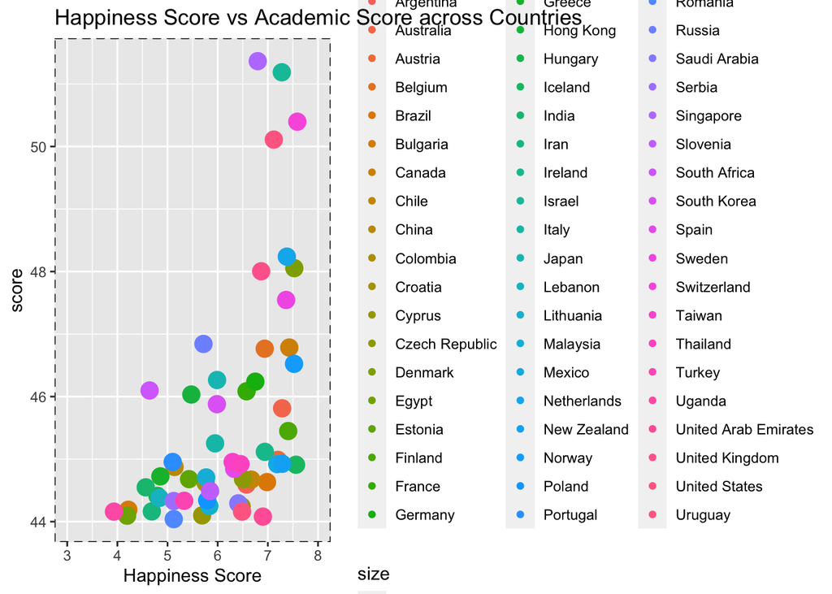

```r
joineddata %>% ggplot(aes(x=`Happiness Score`,y=score, color=country))+geom_point(stat="summary",fun=mean, aes(size=2)) + labs(title="Happiness Score vs Academic Score across Countries")+theme(panel.border = element_rect(linetype = "dashed", fill = NA)) + scale_x_continuous(limits = c(3,8),breaks= seq(3,8,1))
```

This plot provides a summary comparison of the happiness value when compared to the academic value across different countries. The plot’s theme was changed slightly and the scaling was shifted to provide a closer look at the values. The plot follows a very rough positively linear relationship. Which seems to indicate that the higher the mean happiness value for a country, the higher the academic value for a country as well.

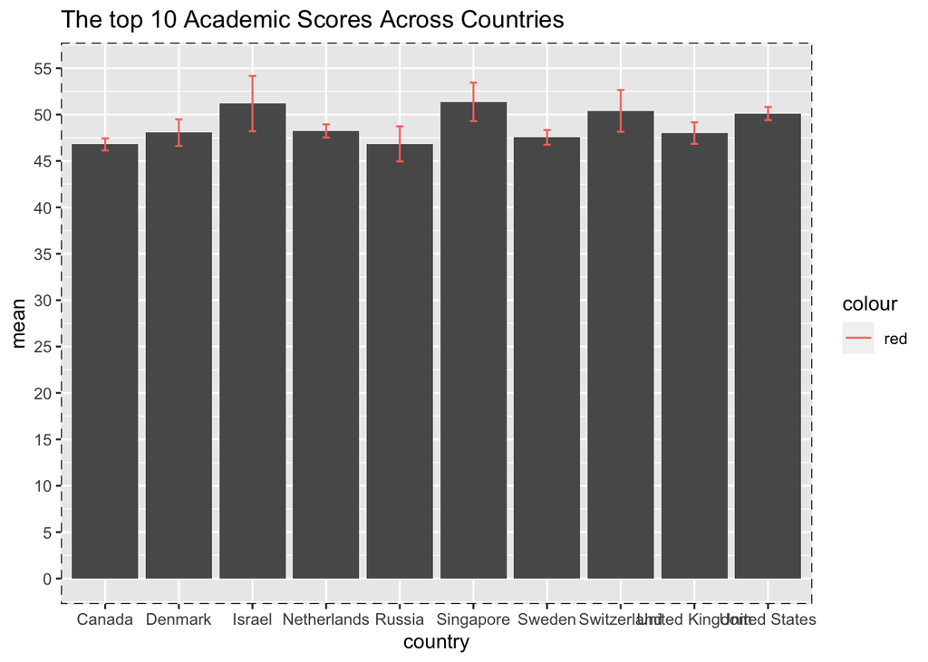

```r
top10<-joineddata %>% group_by(country) %>% summarize(mean=mean(score,na.rm=T), sd=sd(score, na.rm=T), n=n(), se=sd/sqrt(n)) %>% arrange(desc(mean))%>% slice(1:10)
top10 %>% ggplot(aes(x=country,y=mean))+geom_bar(stat="identity") + geom_errorbar(aes(ymin=mean-se, ymax=mean+se, width=.1, color="red")) + labs(title="The top 10 Academic Scores Across Countries")+theme(panel.border = element_rect(linetype = "dashed", fill = NA)) + scale_y_continuous(limits = c(0,55),breaks= seq(0,60,5))
```

This plot visually expresses some of the data presented previously in the summary section. This compares the academic values across the top 10 countries (limited to top 10 for purposes of readability) with the standard error bars. I found it rather interesting that nearly none of these values were significantly different from one another, apart from perhaps Singapore and Canada. Moreover, while this top 10 seems extremely similar to the top 10 of the next plot, this similarity makes any sort of discrepancy between the two all the more glaring.

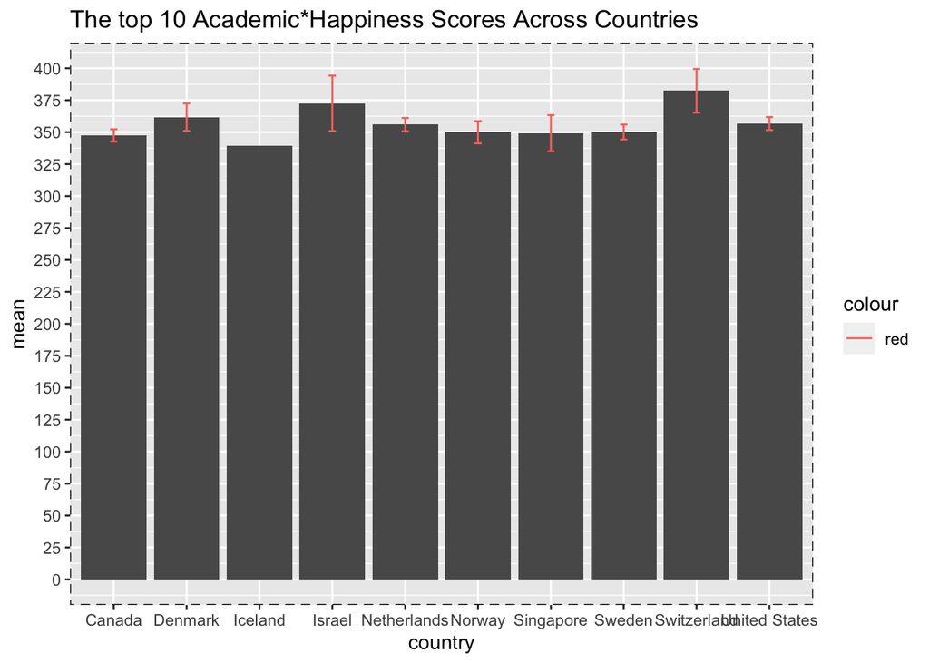

```r
top10_combined<-joineddata %>% group_by(country) %>% summarize(mean=mean(academic_happiness_score,na.rm=T), sd=sd(academic_happiness_score,na.rm=T), n=n(), se=sd/sqrt(n)) %>% arrange(desc(mean))%>% slice(1:10)
top10_combined %>% ggplot(aes(x=country,y=mean))+geom_bar(stat="identity") +geom_errorbar(aes(ymin=mean-se, ymax=mean+se, width=.1, color="red"))+ labs(title="The top 10 Academic*Happiness Scores Across Countries")+theme(panel.border = element_rect(linetype = "dashed", fill = NA))+scale_y_continuous(limits = c(0,400),breaks= seq(0,400,25))
```

As discussed with the previous plot, this plot provides a visual representation of data already somewhat expressed in the summary section, with the addition of standard error bars (except for Iceland). The absence of Russia and the presence of Iceland provides information about these two countries. Given that the previous plot only looked at academic values, it is safe to say that Russsia has a very high academic value but a relatively low happiness value. Furthermore, since Iceland is not in the top 10 of the previous plot, it is safe to say that it’s happiness level is higher that most other countries and allowed it to make it into the top 10 of this variable. This is to say, that given the linear trend seen in the first plot that these two countries could be considered outliers (as Russia has a low happiness value but a high academic value, and Iceland has the inverse of that.)